# 7 Exploratory Data Analysis

Cut é um fator ordenado, fair é pior que good… Muitas variáveis categóricas não tem esse ordenamento então pode valer a pena reordenar com a função reorder por exemplo. Vamos reordenar o boxplot de mpg em relação as das milhas em relação ao tipo de carro, dado que o tipo de carro não tem uma ordem própria.

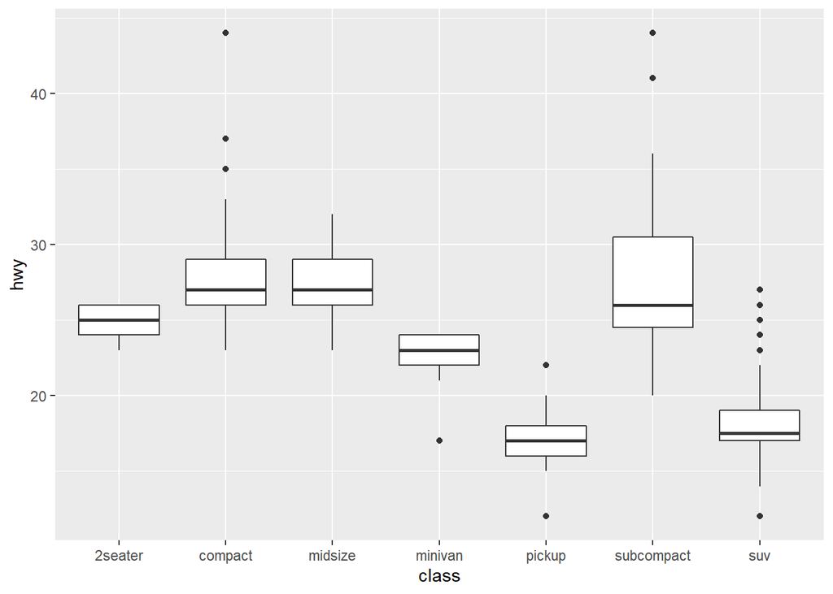

```r
mpg %>% ggplot(aes(class,hwy)) + geom_boxplot()
```

Podemos reordenar para que deixar as classes em ordem de desempenho.

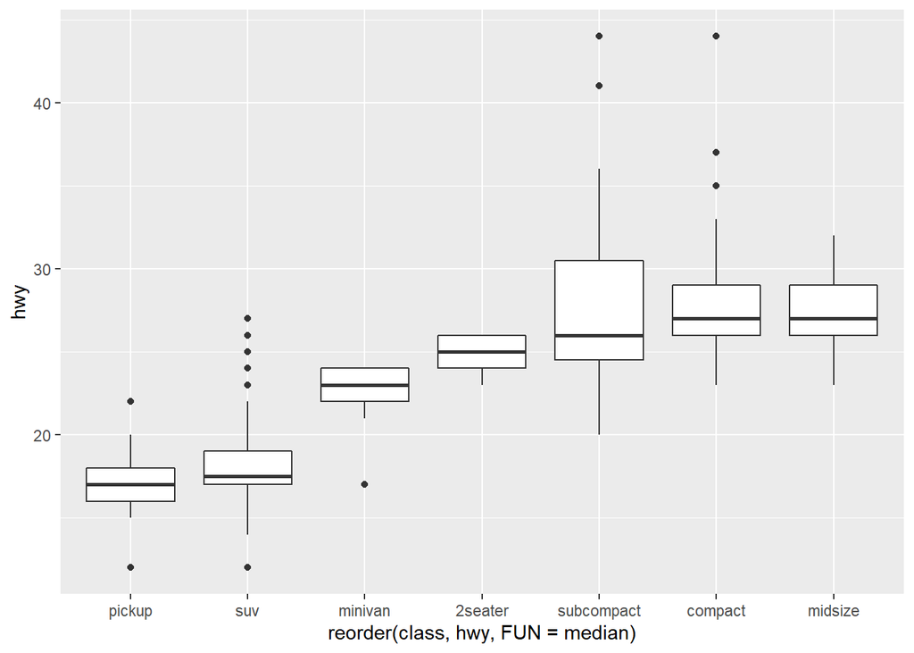

```r
mpg %>% ggplot(aes(reorder(class,hwy,FUN=median),hwy)) + geom_boxplot()
```

Podemos virar o boxplot para visualizar melhor os nomes.

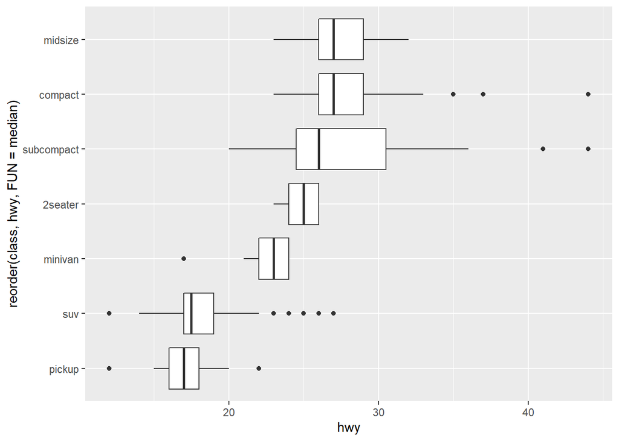

```r
mpg %>% ggplot(aes(reorder(class,hwy,FUN=median),hwy)) + geom_boxplot() + coord_flip()
```